# IMPLEMENTATION OF MACHINE LEARNING MODELS FOR CLASSIFICATION TASKS

This report contains the implementation of Machine Learning models for five different classification tasks. The models are trained and tested are:

1. Random Forest
2. Tree Stumps with AdaBoost
3. Artificial Neural Network
4. K-Nearest Neighbors

Each of the Machine Learning models is implemented in a separate class, which can be instantiated, trained and evaluated on a dataset from the UCI Machine Learning Repository. The models are stratified 5-fold cross-validated. The standard deviation of the accuracy of the models and the average accuracy is calculated and reported.

## To demonstrate the effectiveness of these implementations, the models are trained and tested on the following datasets:

1. Breast Cancer Wisconsin (Diagnostic)
2. Holistic Evaluation of Cars
3. Letter Recognition
4. Ecoli Localization Site
5. Mushroom Edibility

```python
# Import the necessary libraries and modules
import src.constants as CONSTANTS
import src.controllers as CONTROLLERS
# To reload the modules automatically when the code changes
%load_ext autoreload
%autoreload 2
```

## BREAST CANCER WISCONSIN (DIAGNOSTIC)

- **Description**: Features computed from a digitized image of a fine needle aspirate (FNA) of a breast mass describe characteristics of the cell nuclei present in the image.
- **Target Variable Type**: Binary (e.g., malignant or benign).
- **Problem Statement**: Develop a machine learning model that analyzes the characteristics of cell nuclei from digitized images of breast mass FNA to accurately distinguish between benign and malignant tumors.
- **Most Important Performance Metric**: Precision and Recall (F1 Score).
  - **Justification**: For medical diagnostic problems, both false positives and false negatives carry significant consequences. Precision is critical because false positives can lead to unnecessary anxiety, stress, and further invasive testing for patients. Recall is equally important because missing a malignant tumor (false negative) can have life-threatening implications.
  - **Real-Life Scenario**: In a screening program for breast cancer, a high F1 score ensures that the majority of malignancies are correctly identified (high recall) while minimizing the stress and cost of false alarms (high precision).
    - **Note**: The F1 Score is the harmonic mean of precision and recall, providing a balanced evaluation metric for binary classification tasks.

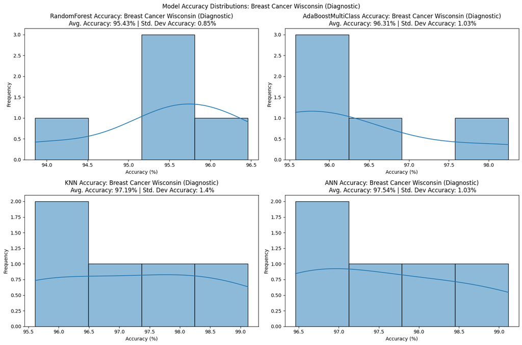

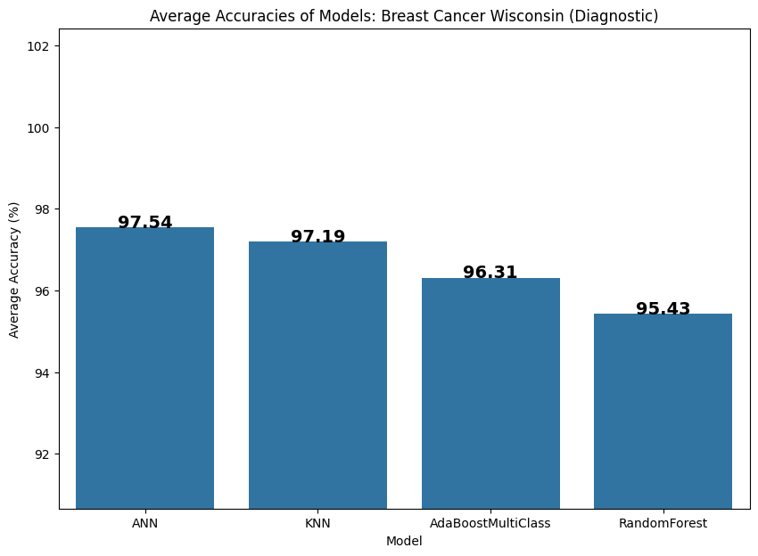

```python
random_forest_breast_cancer_results,adaboost_model_breast_cancer_results, knn_model_breast_cancer_results, ann_model_breast_cancer_results = CONTROLLERS.train_and_validate_all_models(CONSTANTS.BREAST_CANCER_ID)
```

## HOLISTIC EVALUATION OF CARS

- **Description**: Evaluates cars based on overall price, maintenance price, technical characteristics, comfort, and estimated safety.
- **Target Variable Type**: Categorical (e.g., car acceptability ratings such as unacceptable, acceptable, good, or very good).
- **Problem Statement**: Create a classification system that assesses cars based on their price, maintenance cost, technical characteristics, comfort, and safety to predict their acceptability rating.
- **Most Important Performance Metric**: Accuracy.
  - **Justification**: Since the target variable is categorical with multiple classes representing car acceptability, accuracy is a straightforward metric for evaluating overall performance. The distribution among classes may be relatively balanced, and the cost of classification is not as severe as in medical diagnosis.
  - **Real-Life Scenario**: A car manufacturer might use the model to categorize new car models based on their features. High accuracy means that the manufacturer can reliably predict customer acceptance and potentially adjust production plans accordingly.

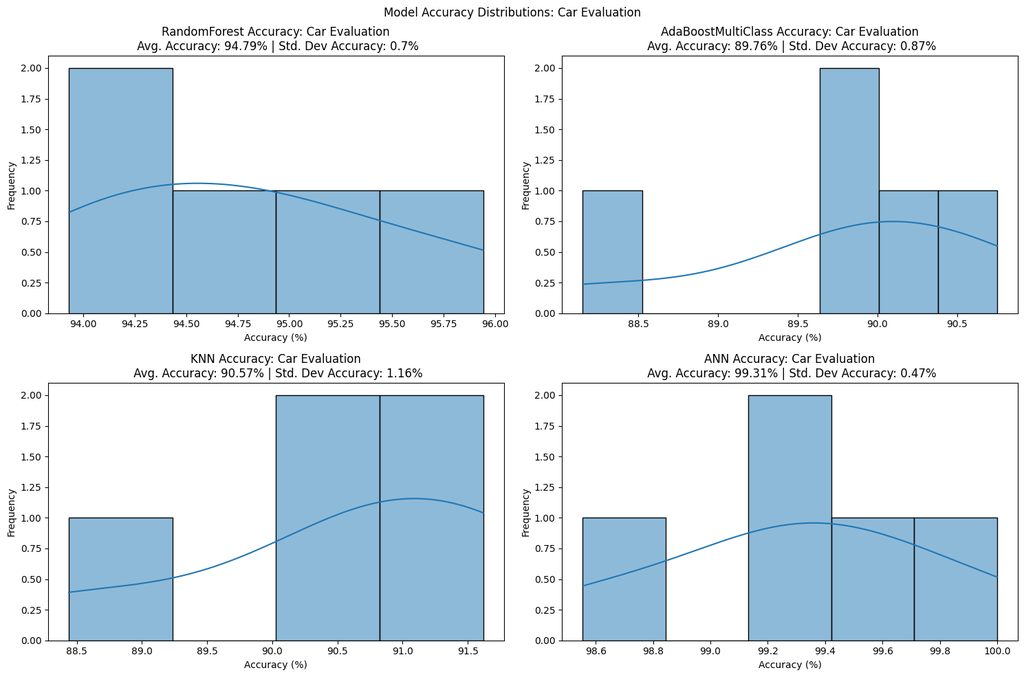

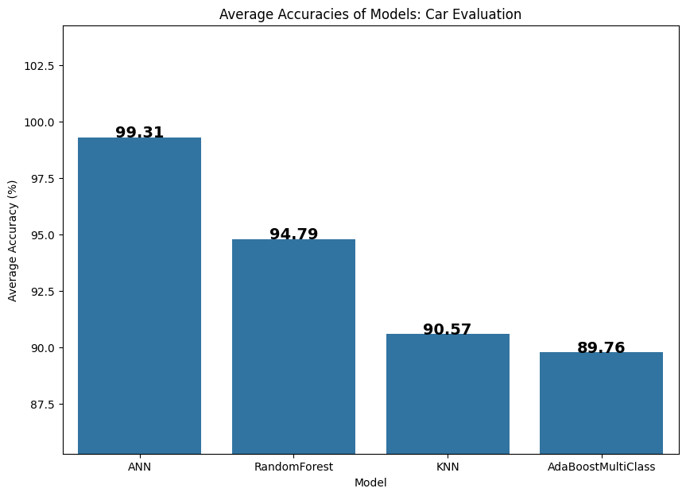

```python
random_forest_car_evaluation_results, adaboost_car_evaluation_results, knn_car_evaluation_results, ann_car_evaluation_results = CONTROLLERS.train_and_validate_all_models(CONSTANTS.CAR_EVALUATION_ID)
```

The best model for the Car Evaluation dataset based on accuracy is the **ANN with an average accuracy of 99.31%.**

## LETTER RECOGNITION

- **Description**: Identifies each of a large number of black-and-white rectangular pixel displays as one of the 26 capital letters in the English alphabet based on 16 primitive numerical attributes.
- **Target Variable Type**: Categorical (26 capital letters).
- **Problem Statement**: Implement an optical character recognition (OCR) system that can identify the 26 capital letters of the English alphabet from black-and-white rectangular pixel displays using statistical moments and edge counts.
- **Most Important Performance Metric**: Accuracy.
  - **Justification**: Given the evenly distributed nature of the target variable (26 letters), and assuming that the cost of classification is uniform across all letters, accuracy provides a simple and effective measure of the model’s overall performance in correctly identifying letters.
  - **Real-Life Scenario**: An automated postal sorting system uses the model to recognize postal codes on envelopes. High accuracy ensures that mail is correctly sorted and delivered promptly, minimizing delays or misdeliveries.

[figure not shown]

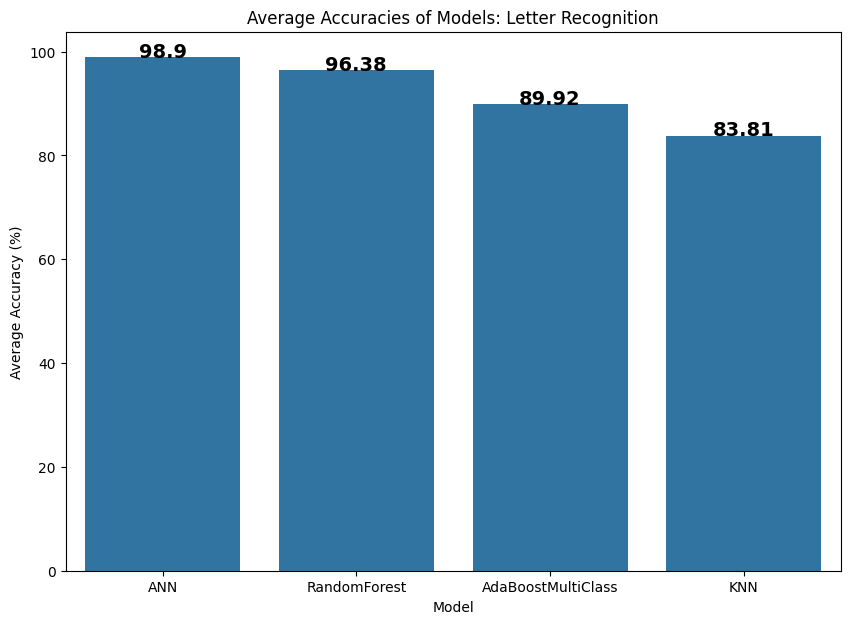

```python
random_forest_letter_recognition_results, adaboost_letter_recognition_results, knn_letter_recognition_results, ann_letter_recognition_results = CONTROLLERS.train_and_validate_all_models(CONSTANTS.LETTER_RECOGNITION_ID)
```

The best model for the Letter Recognition dataset based on accuracy is the **ANN with an average accuracy of 98.9%.**

## ECOLI LOCALIZATION SITE

- **Description**: Data set for predicting protein localization sites in Gram-negative bacteria.
- **Target Variable Type**: Categorical (different localization sites).
- **Problem Statement**: Construct a predictive model to accurately determine the localization sites of proteins in Gram-negative bacteria based on their properties.
- **Most Important Performance Metric**: Multi-class F1 Score.
  - **Justification**: The problem involves classifying proteins into multiple categories of localization sites, where classification could affect subsequent biological research or applications. The F1 Score is essential for evaluating the model’s performance across all classes, taking into account both precision and recall, to ensure accurate predictions for each localization site.
  - **Real-Life Scenario**: In the development of new antibiotics, accurately predicting protein localization can be crucial for targeting bacterial functions. An incorrect prediction could lead to ineffective drug design, highlighting the importance of high precision and recall across all categories.

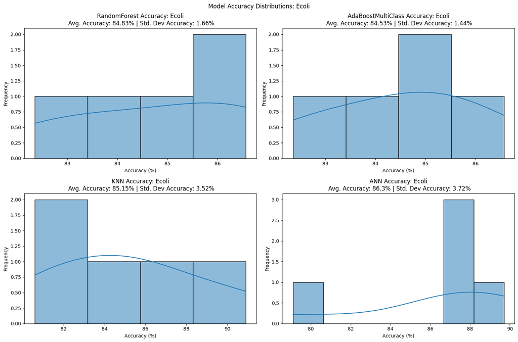

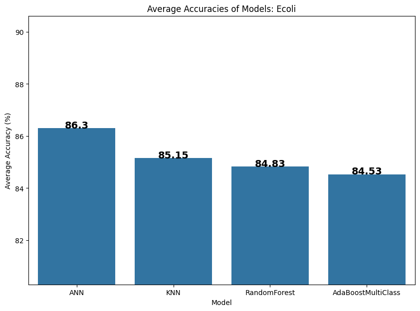

```python
random_forest_ecoli_localization_results, adaboost_ecoli_localization_results, knn_ecoli_localization_results, ann_ecoli_localization_results = CONTROLLERS.train_and_validate_all_models(CONSTANTS.ECOLI_ID)
```

## MUSHROOM EDIBILITY

- **Description**: Descriptions of hypothetical samples corresponding to 23 species of gilled mushrooms categorized by edibility.
- **Target Variable Type**: Binary (edible or poisonous).
- **Problem Statement**: Design a classification algorithm that can predict whether a given mushroom is edible or poisonous based on its characteristics.
- **Most Important Performance Metric**: Recall for the poisonous class.
  - **Justification**: In the context of identifying edible versus poisonous mushrooms, the most critical error to avoid is falsely identifying a poisonous mushroom as edible (false negative for the poisonous class). Thus, while precision is also important, maximizing recall for the poisonous class ensures that potentially deadly mistakes are minimized.
  - **Real-Life Scenario**: A foraging app uses the model to advise users on whether mushrooms found in the wild are edible. High recall for the poisonous class means the app is highly reliable in warning users against consuming dangerous mushrooms, significantly reducing the risk of poisoning.

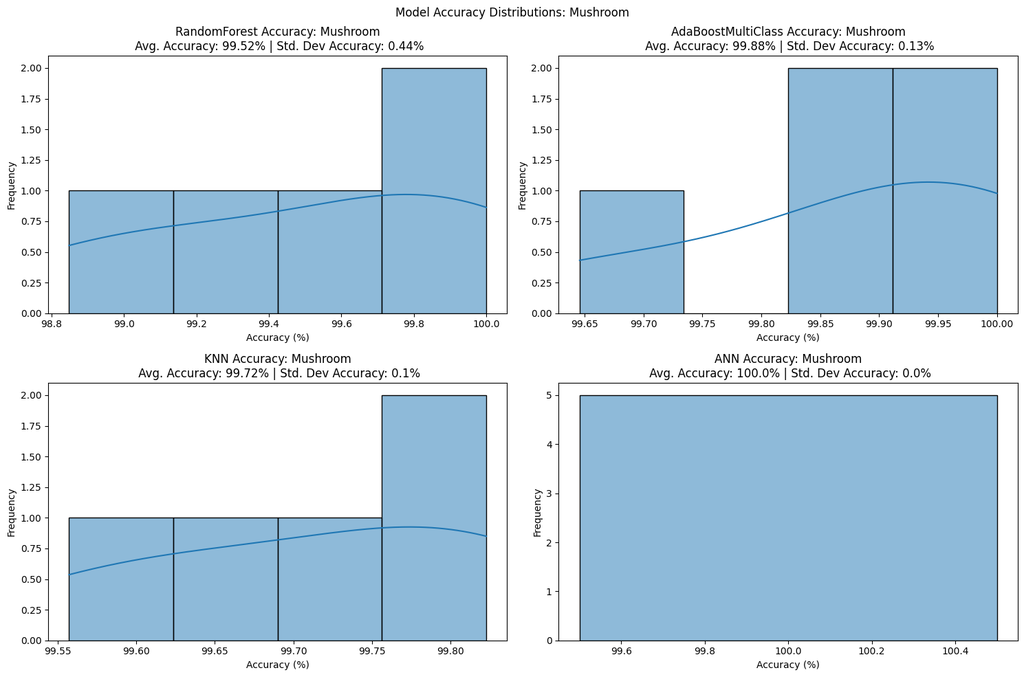

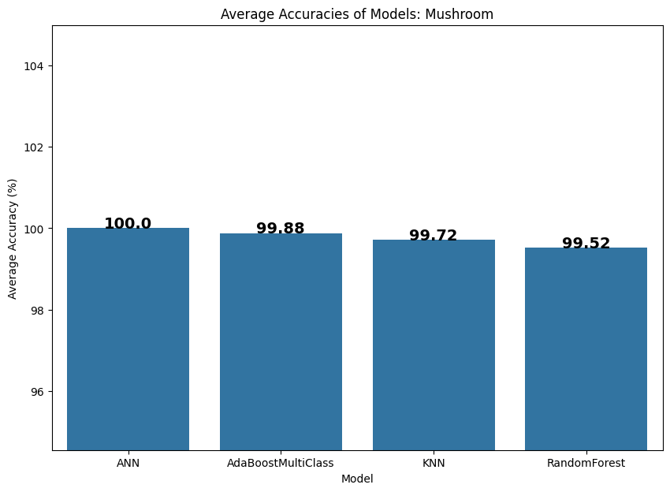

```python
random_forest_mushroom_edibility_results, adaboost_mushroom_edibility_results, knn_mushroom_edibility_results, ann_mushroom_edibility_results = CONTROLLERS.train_and_validate_all_models(
    CONSTANTS.MUSHROOM_ID)
```

The best model for the Mushroom Edibility dataset is the **ANN with an average recall of 100.0%.**